# An example of using PolyAtailor to combine and compare results from different datasets

Mengfei Liu, Xiaohui Wu

2022/5/3

## 1. Overview

Here, we demonstrate the power of PolyAtailor analysis to compare the results of computations on multi different datasets. The function ‘batchCompare’ can compare the overlapping of genes with tails in different datasets, the difference in the proportion of different types of sequences, the difference in the length distribution of poly(A) tails, and the overlap of poly(A) sites and so on. For example, in the following example, we show how to use the ‘batchCompare’ function to analyze and merge the poly(A) tails and poly(A) sites calculations for the PACBIO sequencing Dataset1 and NGS sequencing Dataset2. The ‘batchCompare’ function supports result comparison in four dimensions: sequence, gene, PA sites, tail length.

## 2. Preparation

First, the PACBIO sequencing Dataset1 (SRR8568871/SRR8568872) and NGS sequencing Dataset2 (SRR5314571/SRR5314572) were all downloaded from the NCBI database. Both datasets are from the Hela sample. First, the original fastq files were aligned to the reference genome, and then the alignment results were converted into BAM format files and input into Tail_map function of PolyAtailor to measure tails and poly(A) sites. Once you have done this you can start using the batchCompare function of PolyAtailor to compare the results.

```r
# 1.Download sequence files in fastq format from NCBI
# 2.Align sequences and convert file formats
# 3.Quantitativing poly(A) tails with PolyAtailor
rm(list=ls())
library(PolyAtailor)
#require(devtools)
#install_github("BMILAB/movAPA")
library(movAPA)
library(Rsamtools)
#BiocManager::install("Rsamtools")
#Persistently prefer one function over anothe, in case
conflict_prefer_all("PolyAtailor", "dplyr")
conflict_prefer_all("PolyAtailor", "IRanges")
conflict_prefer("summarise", "dplyr")

## For full-length sequences the longRead parameter is set to T
#here dataset1 is subset of Dataset1 data
data1.path <- system.file("extdata", "./GV_algin/d1_subset.bam", package = "PolyAtailor", mustWork = TRUE)
D1 = tailMap(bamfile=data1.path,mcans=5,minTailLen=8,findUmi = F,longRead=T)
head(D1[,1:4])
#            read_num          chr strand     coord
# 1 SRR8568871.105958 NC_000001.11      - 149842185
# 2  SRR8568871.13378 NC_000001.11      -   8870646
# 3 SRR8568871.134537 NC_000001.11      +  58999617
# 4 SRR8568871.135358 NC_000001.11      + 236483105
# 5 SRR8568871.138552 NC_000001.11      - 149860081
# 6 SRR8568871.141140 NC_000001.11      +  23961696

## For NGS sequences the longread parameter is set to F
#here dataset2 is subset of Dataset2 data
data2.path <- system.file("extdata", "./GV_algin/d2_subset.bam", package = "PolyAtailor", mustWork = TRUE)
D2 = tailMap(bamfile=data2.path,mcans=5,minTailLen=8,findUmi = F,longRead=F)
head(D2[,1:4])
#              read_num          chr strand     coord
# 1  SRR5314571.1089513 NC_000001.11      -   8861006
# 2 SRR5314571.11256375 NC_000001.11      -  96678784
# 3 SRR5314571.12192933 NC_000001.11      -  96678784
# 4 SRR5314571.12237630 NC_000001.11      -  96678791
# 5 SRR5314571.12696790 NC_000001.11      - 121168671
# 6 SRR5314571.13095118 NC_000001.11      -  96678784



# 4.Poly(A) sites determination with PolyAtailor
## example
library(BSgenome.Mmusculus.UCSC.mm10)
#BiocManager::install("BSgenome.Mmusculus.UCSC.mm10")
library(TxDb.Mmusculus.UCSC.mm10.knownGene)
#BiocManager::install("TxDb.Mmusculus.UCSC.mm10.knownGene")
bsgenome = BSgenome.Mmusculus.UCSC.mm10
gffFile = TxDb.Mmusculus.UCSC.mm10.knownGene
chrinfo = system.file("extdata", "./GV_algin/chrinfo.txt", package = "PolyAtailor", mustWork = TRUE)
resultpath = "./result"
if(!dir.exists(resultpath)){
  dir.create(resultpath)
}
bamfile =system.file("extdata", "./GV_algin/GV1subseq.sorted.bam", package = "PolyAtailor", mustWork = TRUE)
conflict_prefer("reduce", "IRanges")
pacD1 = findAndAnnoPAs(chrinfo=chrinfo,bamfile=bamfile,
                       resultpath=resultpath,bsgenome=bsgenome,
                       gffFile=gffFile,sample="D1rep1",mergePAs=T,d=24)
#For example only, please use another set of data
pacD2 = ffindAndAnnoPAs(chrinfo=chrinfo,bamfile=bamfile,
                       resultpath=resultpath,bsgenome=bsgenome,
                       gffFile=gffFile,sample="D1rep2",mergePAs=T,d=24)
```

## 3. Overlap of tailed genes found in the two datasets

The first function of batchCompare is to compare the overlap of tailed genes found in multiple data sets. There are two drawing methods to choose from: the upset graph and the veen graph, which are set by the parameter format. In the figure below, we plot the overlap of tailed genes in replicate 1 of the two datasets in two ways. In the figure, ‘Batch1’ represents repetition 1 of Dataset1, and Batch2 represents repetition 1 of Dataset2.

```r
datalist = list(Batch1 = pacD1@anno, Batch2 = pacD2@anno)
dev.off()
p = batchCompare(datalist=datalist,format="upset",dimension="gene",mycolors=c("#be8ec4","#7ed321"))
p
library(VennDiagram)
p = batchCompare(datalist=datalist,format="veen",dimension="gene",mycolors=c("#be8ec4","#7ed321"))
```

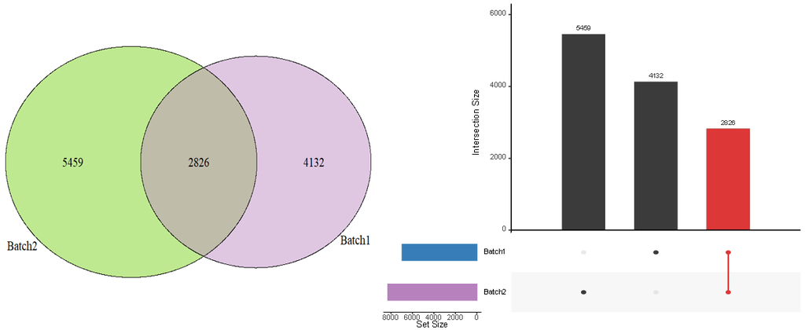

## 4. Comparing the proportions of sequence types in different dataset calculations

When the parameter ‘dimension’ is set to ‘read’, users can quickly compare the proportion of different kinds of sequences in different datasets. In the figure below, we compare the proportions of different types of sequences in repetition 1 of the two datasets. The comparison finds that the two-tail-mixed type sequences and unstructural type sequences in the results of Dataset2 are significantly less.

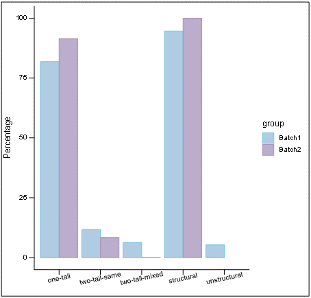

```r
#For example only
datalist = list(Batch1 = D1, Batch2 = D1)
p = batchCompare(datalist,format="bar",dimension="read",mycolors=c("#9bbfdc","#ab99c1"))
p
```

## 5. Comparing the distribution of tail lengths across different datasets

When the parameter ‘dimension’ is set to ‘tail’, users can quickly compare tail length distributions across different datasets. The parameter ‘rep’ can be used to specify whether to compare different repetitions at the same time. The figure below shows the distribution of tail lengths for different replicates of the two datasets.

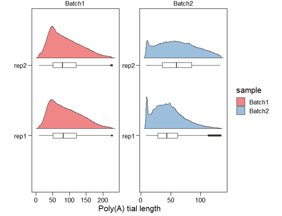

```r
#For example only
datalist = list(Batch1 = D1, Batch2 = D1)
#BiocManager::install("PupillometryR")
library(PupillometryR)
library(ggthemes)
p = batchCompare(datalist,format="bar",dimension="tail",mycolors=c("#f18687","#9bbfdc"),rep=F)
#or
#batchCompare(datalist,format="bar",dimension="tail",mycolors=c("#f18687","#9bbfdc"),rep=T)
p
```

## 6. Comprehensive analysis of poly(A) sites in different datasets

When the parameter ‘dimension’ is set to ‘PACds’, users can quickly compare or merge lists of poly(A) sites in two datasets. The parameter ‘D’ is used to specify the range of bases considered to be the same poly(A) site. The parameter ‘findOvpPACds’ specifies whether to extract overlapping poly(A) site clusters. The parameter ‘annotateByKnownPAC’ specifies whether to combine the two sets of poly(A) site information in an annotated manner. The function finally outputs a list, in which the data slot named ‘OvpPACds’ stores the overlapping poly(A) site statistics, the ‘OvpPACdsList’ data slot stores the overlapping poly(A) site list, and the ‘OvpPACdsAnnotate’ data slot stores the merged poly(A) site list. We used the ‘batchCompare’ function to calculate the overlap ratio of poly(A) sites extracted from repeat 1 of the two datasets, and the parameter ‘d’ was set to 100. The results are as follows:s

```r
PACdslist = list(Batch1 = pacD1, Batch2 = pacD2)
p = batchCompare(PACdslist,dimension="PACds",findOvpPACds=T,annotateByKnownPAC=T,d=100,mycolors=c("#be8ec4","#7ed321"),rep=F)
head(p[['OvpPACds']])  #or head(p$OvpPACds)
# pacD1 pacD2 Total1 Total2 Ovp1 Ovp2 Ovp1Pct Ovp2Pct
# 1    1    1  31289 186626 2404 2775      8%      1%
```

*References*  
Ye W, Liu T, Fu H, et al. movAPA: Modeling and visualization of dynamics of alternative polyadenylation across biological samples[J]. Bioinformatics, 2021, 37(16): 2470-2472.  
Liu Y, Nie H, Liu H, et al. Poly (A) inclusive RNA isoform sequencing (PAIso− seq) reveals wide-spread non-adenosine residues within RNA poly (A) tails[J]. Nature communications, 2019, 10(1): 1-13.  
Legnini I, Alles J, Karaiskos N, et al. FLAM-seq: full-length mRNA sequencing reveals principles of poly (A) tail length control[J]. Nature methods, 2019, 16(9): 879-886.